# STA 363 HW7

Ethan Gutknecht

12/3/2021

## Data Set

This data set was analyzed in [Muggeo and Ferrara (2008)](https://ideas.repec.org/a/eee/csdana/v52y2008i5p2529-2537.html). It contains information from 683 production workers, and it recorded the following variables:

- `kwit` – *“binary outcome, with value of 1 indicating if the worker quits within six months of starting a new job, 0 otherwise”*
- `y` – *“numerical observed standardized physical productivity measure for the worker after the initial training period”*
- `sex` – *“a dummy variable for the workers’ sex, 0=female, 1=male”*
- `dex` – *“a score on a physical dexterity exam administered before the worker was hired”*
- `lex` – *“the number of years of education of the worker”*
- `job_tenure` – *“actual duration of employment”*
- `censored` – *“censoring indicator, if the censoring indicator is 0 then the corresponding duration is censored, i.e., they are observed by the end of the observation time period, but they entered the company less than 6 months by then.”*

```r
library(tidyverse)
library(GGally)
library(ggfortify)
library(leaps)
library(car)
library(tidymodels)
library(knitr)
library(gridExtra)
library(lindia)
library(leaps)
library(car)
library(caret)
library(kableExtra)


dat1  = read.table("http://www.econ.uiuc.edu/~roger/courses/471/data/weco.dat",header = TRUE)
```

## Part 1: Odds

#### Question 1: Data filtering is done in the following step. What does it do? (1 pt)

```r
dat2<-dat1%>%
  filter(censored==1)
```

### **Using the updated data set *`dat2`* to answer the following questions:**

#### Question 2: Compute the odds that a worker quits within six months of starting a new job. (2 pts)

```r
xtabs(~ kwit, data=dat2)
```

```
## kwit
##   0   1
## 400 153
```

```r
(153 / 683)
```

```
## [1] 0.2240117
```

#### Question 3: Does the odds of a worker quits within six months of starting a new job vary by gender? Compute the odds that a worker quits within six months of starting a new job for each gender group. Compare these values to address the question. (3pts)

```r
# Get us the results  (Y-AXIS: KWIT, X-AXIS: SEX)
xtabs(~ kwit + sex, data=dat2)
```

```
##     sex
## kwit   0   1
##    0 172 228
##    1  52 101
```

```r
# Males (1):
(101/228)
```

```
## [1] 0.4429825
```

```r
# Females (0):
(52/172)
```

```
## [1] 0.3023256
```

**There is a difference between the two ratios. Males have a ratio of 0.443 and females have a ratio of 0.302. There is higher odds that a male will leave his job within six months compared to a female.**

## Part 2: Simple Logistic Regression

#### Question 4: Build one or more plots to explore how *`dex`* predicts whether a worker quits within six months of starting a new job. Briefly discuss the results of your plot(s). (4pts)

```r
# Create model
linearReg <- lm(kwit ~ dex, data=dat2)
summary(linearReg)
```

```
##
## Call:
## lm(formula = kwit ~ dex, data = dat2)
##
## Residuals:
##     Min      1Q  Median      3Q     Max
## -0.6739 -0.3154 -0.1833  0.5336  1.0620
##
## Coefficients:
##             Estimate Std. Error t value Pr(>|t|)
## (Intercept)  1.10797    0.11643   9.516  < 2e-16 ***
## dex         -0.01887    0.00261  -7.229 1.63e-12 ***
## ---
## Signif. codes:  0 '***' 0.001 '**' 0.01 '*' 0.05 '.' 0.1 ' ' 1
##
## Residual standard error: 0.4283 on 551 degrees of freedom
## Multiple R-squared:  0.08662,    Adjusted R-squared:  0.08497
## F-statistic: 52.26 on 1 and 551 DF,  p-value: 1.634e-12
```

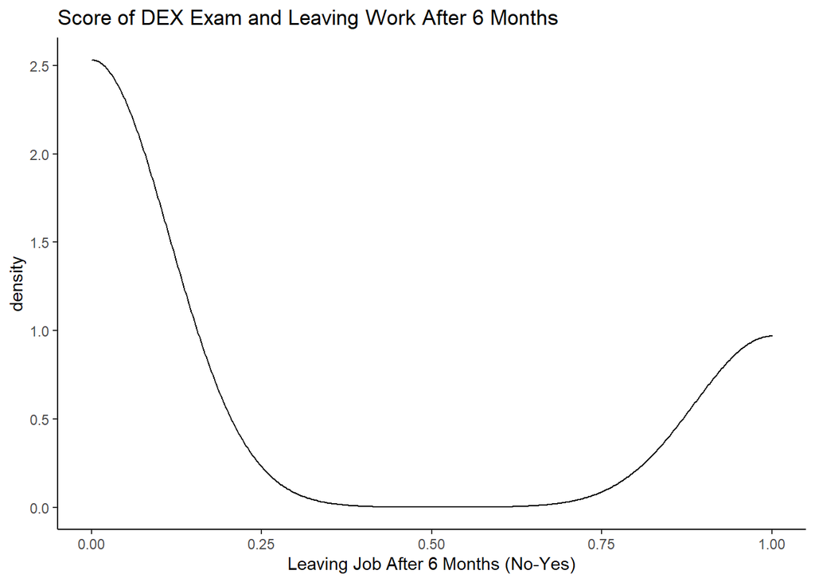

```r
# Graph
ggplot(dat2) +
  geom_density(aes(kwit, fill=dex), alpha=0.2)+
  labs(x="Leaving Job After 6 Months (No-Yes)",
       title="Score of DEX Exam and Leaving Work After 6 Months") +
  theme_classic()
```

**It seems like there is a higher density of people that dont leave their job after six months when using the DEX exam as a predictor.**

#### Question 5: Build a simple logistic model to statistically determine if the *`dex`* predicts the probability that a worker quits within six months of starting a new job. Support your findings with an appropriate hypothesis test. (4pts)

```r
# Create model
fit <- glm(kwit ~ dex, data=dat2, family=binomial(link=logit))
summary(fit)
```

```
##
## Call:
## glm(formula = kwit ~ dex, family = binomial(link = logit), data = dat2)
##
## Deviance Residuals:
##     Min       1Q   Median       3Q      Max
## -1.6997  -0.8405  -0.6041   1.1784   2.4694
##
## Coefficients:
##             Estimate Std. Error z value Pr(>|z|)
## (Intercept)  3.63826    0.68643   5.300 1.16e-07 ***
## dex         -0.10707    0.01618  -6.619 3.61e-11 ***
## ---
## Signif. codes:  0 '***' 0.001 '**' 0.01 '*' 0.05 '.' 0.1 ' ' 1
##
## (Dispersion parameter for binomial family taken to be 1)
##
##     Null deviance: 652.30  on 552  degrees of freedom
## Residual deviance: 601.03  on 551  degrees of freedom
## AIC: 605.03
##
## Number of Fisher Scoring iterations: 4
```

```r
# Hypothesis Test
null.fit <- glm(kwit ~ 1, data=dat2, family=binomial(link=logit))
anova(null.fit, fit, test="LRT")
```

```
## Analysis of Deviance Table
##
## Model 1: kwit ~ 1
## Model 2: kwit ~ dex
##   Resid. Df Resid. Dev Df Deviance  Pr(>Chi)
## 1       552     652.30
## 2       551     601.03  1    51.27 8.049e-13 ***
## ---
## Signif. codes:  0 '***' 0.001 '**' 0.01 '*' 0.05 '.' 0.1 ' ' 1
```

**Based on our model it seems that the DEX score predicts if a person will stay over 6 months. Our LRT hypothesis test correctly supports this claim.**

## Part 3: Multiple Logistic Regression Models

#### Question 6: Fit a multiple logistic regression model with `y`, `sex`, `dex` and `lex` to predict the probability that a worker quits within six months of starting a new job. Conduct an appropriate test to determine whether this model significantly predicts the probability that a worker quits within six months of starting a new job. (4pts)

```r
# Multiple Regression
MR.fit <- glm(kwit ~ y + sex + dex + lex, data=dat2, family=binomial(link=logit))
MR.null.fit <- glm(kwit ~ 1, data=dat2, family=binomial(link=logit))

# Get results
anova(MR.null.fit, MR.fit, test="LRT")
```

```
## Analysis of Deviance Table
##
## Model 1: kwit ~ 1
## Model 2: kwit ~ y + sex + dex + lex
##   Resid. Df Resid. Dev Df Deviance Pr(>Chi)
## 1       552     652.30
## 2       548     591.23  4   61.068 1.73e-12 ***
## ---
## Signif. codes:  0 '***' 0.001 '**' 0.01 '*' 0.05 '.' 0.1 ' ' 1
```

```r
summary(MR.fit)
```

```
##
## Call:
## glm(formula = kwit ~ y + sex + dex + lex, family = binomial(link = logit),
##     data = dat2)
##
## Deviance Residuals:
##     Min       1Q   Median       3Q      Max
## -1.6265  -0.8088  -0.6007   1.0476   2.4334
##
## Coefficients:
##             Estimate Std. Error z value Pr(>|z|)
## (Intercept)  2.48808    1.58656   1.568  0.11683
## y            0.03969    0.09329   0.425  0.67049
## sex          0.65536    0.22737   2.882  0.00395 **
## dex         -0.11925    0.02018  -5.908 3.45e-09 ***
## lex          0.05773    0.08552   0.675  0.49961
## ---
## Signif. codes:  0 '***' 0.001 '**' 0.01 '*' 0.05 '.' 0.1 ' ' 1
##
## (Dispersion parameter for binomial family taken to be 1)
##
##     Null deviance: 652.30  on 552  degrees of freedom
## Residual deviance: 591.23  on 548  degrees of freedom
## AIC: 601.23
##
## Number of Fisher Scoring iterations: 4
```

**This model is significant because the P value for the model is below 0.05. But there are predictor variables that are not significant.**

#### Question 7: Are there predictors that are not significant in the model from Question 6? If so, please create a new model by removing this(these) variable(s) from the model from Question 6, and compare the updated model vs. the model from Questions 6, using a reduced model test. (4pts)

```r
# Multiple Regression
MR.fit.2 <- glm(kwit ~ sex + dex, data=dat2, family=binomial(link=logit))

# Get results
anova(MR.fit.2, MR.fit, test="LRT")
```

```
## Analysis of Deviance Table
##
## Model 1: kwit ~ sex + dex
## Model 2: kwit ~ y + sex + dex + lex
##   Resid. Df Resid. Dev Df Deviance Pr(>Chi)
## 1       550     591.81
## 2       548     591.23  2  0.57839   0.7489
```

#### Question 8: The starter file contains some code to help you along on this problem. Build a table to compare the AIC, BIC and a Pseudo-R-squared for the models fit in questions 5, 6 and 7. Which model is best with respect to each metric? (4pts)

```r
# Simple Linear
glance(fit) %>%
  mutate(Pseudo_Rsquared = (null.deviance-deviance)/null.deviance*100)
```

```
## # A tibble: 1 x 9
##   null.deviance df.null logLik   AIC   BIC deviance df.residual  nobs
##           <dbl>   <int>  <dbl> <dbl> <dbl>    <dbl>       <int> <int>
## 1          652.     552  -301.  605.  614.     601.         551   553
## # ... with 1 more variable: Pseudo_Rsquared <dbl>
```

```r
# Full Model
glance(MR.fit) %>%
  mutate(Pseudo_Rsquared = (null.deviance-deviance)/null.deviance*100)
```

```
## # A tibble: 1 x 9
##   null.deviance df.null logLik   AIC   BIC deviance df.residual  nobs
##           <dbl>   <int>  <dbl> <dbl> <dbl>    <dbl>       <int> <int>
## 1          652.     552  -296.  601.  623.     591.         548   553
## # ... with 1 more variable: Pseudo_Rsquared <dbl>
```

```r
# Reduced Model
glance(MR.fit.2) %>%
  mutate(Pseudo_Rsquared = (null.deviance-deviance)/null.deviance*100)
```

```
## # A tibble: 1 x 9
##   null.deviance df.null logLik   AIC   BIC deviance df.residual  nobs
##           <dbl>   <int>  <dbl> <dbl> <dbl>    <dbl>       <int> <int>
## 1          652.     552  -296.  598.  611.     592.         550   553
## # ... with 1 more variable: Pseudo_Rsquared <dbl>
```

**The reduced model (the third one) is the best out of three since they have the lowest AIC and BIC values.**

#### Question 9: Code was supplied for a Pseudo-R-squared calculation in question 8. Explain how this value mimics that of the traditional R-squared value used in multiple linear regression. (4pts)

**This value looks at the predictor error compared to the variance in response. This value will help predict the unexplained variance in the data.**

#### Question 10: For the model with the best BIC, of those fit in questions 5, 6, or 7, interpret the coefficient associated with `sex`. Be sure to explain this coefficient in terms of odds (not log-odds, which do not provide a nice interpretation). How does this compare to the results in question 3? Why might they be similar/different? (4pts)

```r
# Get Summary
summary(MR.fit.2)
```

```
##
## Call:
## glm(formula = kwit ~ sex + dex, family = binomial(link = logit),
##     data = dat2)
##
## Deviance Residuals:
##     Min       1Q   Median       3Q      Max
## -1.5895  -0.8092  -0.5974   1.0503   2.4259
##
## Coefficients:
##             Estimate Std. Error z value Pr(>|z|)
## (Intercept)  3.55538    0.69022   5.151 2.59e-07 ***
## sex          0.63073    0.21135   2.984  0.00284 **
## dex         -0.11410    0.01649  -6.918 4.57e-12 ***
## ---
## Signif. codes:  0 '***' 0.001 '**' 0.01 '*' 0.05 '.' 0.1 ' ' 1
##
## (Dispersion parameter for binomial family taken to be 1)
##
##     Null deviance: 652.30  on 552  degrees of freedom
## Residual deviance: 591.81  on 550  degrees of freedom
## AIC: 597.81
##
## Number of Fisher Scoring iterations: 4
```

**Since the coefficient is 0.6307 and not negative, it means that as a male you are getting a higher chance to leave your job within six months. This reflects what we said in question three.**

## Part 4: Prediction

#### Answer

```r
dat_test <- dat1 %>%
    filter(censored==0)

# Simple Linear
dat_test<-dat_test%>%
  mutate(kwit.predict.1 = predict(fit, newdata=dat_test,
                            type="response"))

# Full Model
dat_test<-dat_test%>%
  mutate(kwit.predict.2 = predict(MR.fit, newdata=dat_test,
                            type="response"))

# Reduced model
dat_test<-dat_test%>%
  mutate(kwit.predict.3 = predict(MR.fit.2, newdata=dat_test,
                            type="response"))
```

```r
predict(MR.fit.2, newdata=data.frame(sex=0, y=13, dex=40, lex=10), type="response")
```

```
##         1
## 0.2672315
```